# 4. Backtest

- This notebook simulates trading strategies based on model outputs from `predictions.csv`, evaluated over the May 2017 – December 2024 test period.
- Two strategy types are tested for each of the 7 models (RF-252, RF-504, XGB-252, XGB-504, LGB-252, LGB-504, and the Ensemble): **long-flat** (long on predicted UP days, flat otherwise) and **long-short** (long on predicted UP days, short on predicted DOWN days).
- Transaction costs are modelled as the sum of commission, spread, and slippage, applied on every position change. The size of the change determines the cost: entering or exiting a position costs 1×, reversing from long to short (or vice versa) costs 2×.
- Realistic transaction costs are modelled as 3 basis points per trade (1 bp each for commission, bid-ask spread, and slippage), consistent with typical costs of trading a liquid ETF such as SPY.
- Each strategy is evaluated against a buy-and-hold SPY benchmark using: annualised return, annualised volatility, Sharpe ratio, maximum drawdown, and average drawdown.
- Sharpe ratio is computed using the 10-Year Treasury yield (DGS10) as the risk-free rate.
- The backtest is run under two cost scenarios — **zero costs** and **realistic costs**.

## Setup

```python
# Importing libraries
import pandas as pd
import numpy as np
import matplotlib.pyplot as plt
```

```python
# Loading the predictions dataset
predictions = pd.read_csv("../Data/predictions.csv", index_col="date", parse_dates=True)
predictions.head()
```

| date | spy_return | y_true | rw | rf252 | rf252_prob | rf504 | rf504_prob | xgb252 | xgb252_prob | xgb504 | xgb504_prob | lgb252 | lgb252_prob | lgb504 | lgb504_prob | ensemble | ensemble_prob |
| --- | --- | --- | --- | --- | --- | --- | --- | --- | --- | --- | --- | --- | --- | --- | --- | --- | --- |
| 2017-05-10 | 0.001796 | 1.0 | 0.0 | 1.0 | 0.506749 | 1.0 | 0.508959 | 0 | 0.409106 | 0 | 0.465402 | 0.0 | 0.117571 | 0.0 | 0.424201 | 0 | 0.405331 |
| 2017-05-11 | -0.002043 | 0.0 | 1.0 | 1.0 | 0.540898 | 1.0 | 0.573079 | 1 | 0.679007 | 1 | 0.590294 | 1.0 | 0.905800 | 1.0 | 0.774286 | 1 | 0.677227 |
| 2017-05-12 | -0.001671 | 0.0 | 0.0 | 1.0 | 0.526623 | 1.0 | 0.534697 | 1 | 0.523311 | 1 | 0.791502 | 1.0 | 0.923659 | 1.0 | 0.868604 | 1 | 0.694733 |
| 2017-05-15 | 0.005523 | 1.0 | 0.0 | 0.0 | 0.457485 | 1.0 | 0.500249 | 0 | 0.328764 | 0 | 0.474599 | 0.0 | 0.469020 | 1.0 | 0.770665 | 1 | 0.500130 |
| 2017-05-16 | -0.000916 | 0.0 | 1.0 | 0.0 | 0.497455 | 1.0 | 0.525468 | 1 | 0.571459 | 0 | 0.414226 | 1.0 | 0.597692 | 1.0 | 0.759749 | 1 | 0.561008 |

```python
# Loading DGS10 risk-free rate (10-Year Treasury)
dgs10 = pd.read_csv("../Data/dgs10.csv", index_col="observation_date", parse_dates=True)
dgs10 = dgs10["DGS10"].ffill() / 100 / 252  # convert to daily rate
```

## Backtest function

```python
def backtest(predictions, pred_col, mode, commission=0, spread=0, slippage=0):

    df = predictions[["spy_return"]].copy()

    if mode == "long_flat":
        df["signal"] = predictions[pred_col].map({1: 1, 0: 0})
    else:
        df["signal"] = predictions[pred_col].map({1: 1, 0: -1})

    position_change = (df["signal"] - df["signal"].shift(1)).abs()
    position_change.iloc[0] = 0
    total_cost = commission + spread + slippage
    df["net_return"]   = df["signal"] * df["spy_return"] - position_change * total_cost
    df["equity_strat"] = (1 + df["net_return"]).cumprod()
    df["equity_bnh"]   = (1 + df["spy_return"]).cumprod()

    def _metrics(returns, label):
        rf_daily = dgs10.reindex(returns.index).ffill()
        excess   = returns - rf_daily
        n        = len(returns)
        total    = (1 + returns).prod() - 1
        ann_ret  = (1 + total) ** (252 / n) - 1
        ann_vol  = returns.std() * np.sqrt(252)
        sharpe   = excess.mean() / excess.std() * np.sqrt(252)
        equity   = (1 + returns).cumprod()
        dd       = (equity - equity.cummax()) / equity.cummax()
        return {
            "total_return":   round(total, 4),
            "ann_return":     round(ann_ret, 4),
            "ann_volatility": round(ann_vol, 4),
            "sharpe":         round(sharpe, 4),
            "max_drawdown":   round(dd.min(), 4),
            "avg_drawdown":   round(dd[dd < 0].mean(), 4),
            "strategy/model": label,
        }

    metrics = pd.DataFrame([
        _metrics(df["spy_return"], "Buy & Hold"),
        _metrics(df["net_return"], pred_col),
    ]).set_index("strategy/model")

    return metrics, df
```

## Costs setup

```python
# Zero costs
costs_zero = dict(commission=0.0000, spread=0.0000, slippage=0.0000)

# Realistic costs
costs_real = dict(commission=0.0001, spread=0.0001, slippage=0.0001)
```

```python
# Backtest run
models = {
    "Random walk": "rw",
    "RF-252":      "rf252",
    "RF-504":      "rf504",
    "XGB-252":     "xgb252",
    "XGB-504":     "xgb504",
    "LGB-252":     "lgb252",
    "LGB-504":     "lgb504",
    "Ensemble":    "ensemble",
}

results = {}

for scenario_name, costs in [("Zero costs", costs_zero), ("Realistic costs", costs_real)]:
    rows_lf, equity_lf = [], {}
    rows_ls, equity_ls = [], {}

    for label, pred_col in models.items():
        m_lf, df_lf = backtest(predictions=predictions, pred_col=pred_col, mode="long_flat",  **costs)
        m_ls, df_ls = backtest(predictions=predictions, pred_col=pred_col, mode="long_short", **costs)
        rows_lf.append(m_lf.loc[pred_col].rename(label))
        rows_ls.append(m_ls.loc[pred_col].rename(label))
        equity_lf[label] = df_lf["equity_strat"]
        equity_ls[label] = df_ls["equity_strat"]

    bnh_equity = df_lf["equity_bnh"]
    bnh_row    = m_lf.loc["Buy & Hold"].rename("Buy & Hold")

    results[scenario_name] = {
        "lf":        pd.concat([bnh_row.to_frame().T, pd.DataFrame(rows_lf)]),
        "ls":        pd.concat([bnh_row.to_frame().T, pd.DataFrame(rows_ls)]),
        "equity_lf": equity_lf,
        "equity_ls": equity_ls,
    }

bnh_equity_global = bnh_equity

for scenario_name, res in results.items():
    print(f"\n{'='*60}")
    print(f"Scenario: {scenario_name}")
    print(f"{'='*60}")
    print("Long-Flat:")
    display(res["lf"])
    print("Long-Short:")
    display(res["ls"])
```

```
============================================================
Scenario: Zero costs
============================================================
Long-Flat:
```

|  | total_return | ann_return | ann_volatility | sharpe | max_drawdown | avg_drawdown |
| --- | --- | --- | --- | --- | --- | --- |
| Buy & Hold | 1.4477 | 0.1244 | 0.1879 | 0.5795 | -0.3410 | -0.0637 |
| Random walk | 0.4564 | 0.0505 | 0.1205 | 0.2529 | -0.2871 | -0.0901 |
| RF-252 | 0.8516 | 0.0840 | 0.1296 | 0.4862 | -0.1982 | -0.0674 |
| RF-504 | 0.9203 | 0.0892 | 0.1330 | 0.5130 | -0.2858 | -0.0797 |
| XGB-252 | 1.3330 | 0.1173 | 0.1426 | 0.6661 | -0.2051 | -0.0376 |
| XGB-504 | 1.0749 | 0.1003 | 0.1495 | 0.5399 | -0.3086 | -0.0614 |
| LGB-252 | 1.0249 | 0.0968 | 0.1458 | 0.5280 | -0.2686 | -0.0411 |
| LGB-504 | 0.7694 | 0.0776 | 0.1452 | 0.4075 | -0.3664 | -0.1057 |
| Ensemble | 1.4115 | 0.1222 | 0.1471 | 0.6798 | -0.2649 | -0.0650 |

```
Long-Short:
```

|  | total_return | ann_return | ann_volatility | sharpe | max_drawdown | avg_drawdown |
| --- | --- | --- | --- | --- | --- | --- |
| Buy & Hold | 1.4477 | 0.1244 | 0.1879 | 0.5795 | -0.3410 | -0.0637 |
| Random walk | -0.2609 | -0.0388 | 0.1881 | -0.2550 | -0.6099 | -0.3481 |
| RF-252 | 0.2158 | 0.0259 | 0.1880 | 0.0912 | -0.5910 | -0.2890 |
| RF-504 | 0.3163 | 0.0367 | 0.1880 | 0.1465 | -0.4660 | -0.1454 |
| XGB-252 | 0.9835 | 0.0938 | 0.1879 | 0.4319 | -0.3592 | -0.1076 |
| XGB-504 | 0.5929 | 0.0629 | 0.1880 | 0.2795 | -0.3919 | -0.1408 |
| LGB-252 | 0.5043 | 0.0549 | 0.1880 | 0.2397 | -0.4371 | -0.1462 |
| LGB-504 | 0.1470 | 0.0181 | 0.1880 | 0.0504 | -0.6046 | -0.2340 |
| Ensemble | 1.1403 | 0.1048 | 0.1879 | 0.4850 | -0.4197 | -0.1318 |

```
============================================================
Scenario: Realistic costs
============================================================
Long-Flat:
```

|  | total_return | ann_return | ann_volatility | sharpe | max_drawdown | avg_drawdown |
| --- | --- | --- | --- | --- | --- | --- |
| Buy & Hold | 1.4477 | 0.1244 | 0.1879 | 0.5795 | -0.3410 | -0.0637 |
| Random walk | 0.0946 | 0.0119 | 0.1205 | -0.0576 | -0.3185 | -0.1416 |
| RF-252 | 0.5379 | 0.0580 | 0.1296 | 0.2986 | -0.2491 | -0.0869 |
| RF-504 | 0.6198 | 0.0652 | 0.1331 | 0.3452 | -0.3105 | -0.0850 |
| XGB-252 | 0.8743 | 0.0858 | 0.1427 | 0.4650 | -0.2075 | -0.0398 |
| XGB-504 | 0.6408 | 0.0670 | 0.1496 | 0.3340 | -0.3144 | -0.0683 |
| LGB-252 | 0.6267 | 0.0658 | 0.1458 | 0.3312 | -0.2741 | -0.0492 |
| LGB-504 | 0.4306 | 0.0480 | 0.1454 | 0.2157 | -0.3883 | -0.1142 |
| Ensemble | 0.9677 | 0.0927 | 0.1472 | 0.4986 | -0.2815 | -0.0693 |

```
Long-Short:
```

|  | total_return | ann_return | ann_volatility | sharpe | max_drawdown | avg_drawdown |
| --- | --- | --- | --- | --- | --- | --- |
| Buy & Hold | 1.4477 | 0.1244 | 0.1879 | 0.5795 | -0.3410 | -0.0637 |
| Random walk | -0.5827 | -0.1082 | 0.1881 | -0.6526 | -0.6993 | -0.4083 |
| RF-252 | -0.1613 | -0.0228 | 0.1880 | -0.1677 | -0.6371 | -0.3364 |
| RF-504 | -0.0634 | -0.0085 | 0.1881 | -0.0904 | -0.5379 | -0.2013 |
| XGB-252 | 0.2802 | 0.0329 | 0.1879 | 0.1266 | -0.4222 | -0.1476 |
| XGB-504 | -0.0040 | -0.0005 | 0.1883 | -0.0474 | -0.5109 | -0.2244 |
| LGB-252 | -0.0293 | -0.0039 | 0.1880 | -0.0655 | -0.5236 | -0.2407 |
| LGB-504 | -0.2502 | -0.0370 | 0.1883 | -0.2452 | -0.6774 | -0.2939 |
| Ensemble | 0.4251 | 0.0475 | 0.1879 | 0.2014 | -0.4755 | -0.1780 |

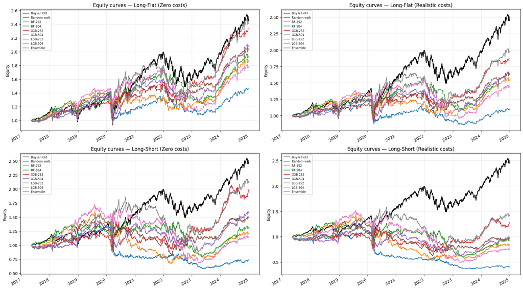

```python
# Equity graphs for all models under different scenarios
fig, axes = plt.subplots(2, 2, figsize=(18, 10))

scenario_names  = list(results.keys())
strategy_keys   = ["lf", "ls"]
strategy_titles = ["Long-Flat", "Long-Short"]

for col, scenario_name in enumerate(scenario_names):
    for row, (strat_key, strat_title) in enumerate(zip(strategy_keys, strategy_titles)):
        ax = axes[row][col]
        bnh_equity_global.plot(ax=ax, label="Buy & Hold", color="black", linewidth=1.5)
        for label, equity in results[scenario_name][f"equity_{strat_key}"].items():
            equity.plot(ax=ax, label=label, linewidth=1.2)
        ax.set_title(f"Equity curves — {strat_title} ({scenario_name})")
        ax.set_ylabel("Equity")
        ax.set_xlabel("")
        ax.legend(fontsize=7)
        ax.grid(alpha=0.3)

plt.tight_layout()
plt.show()
```

```python
# Yearly breakdown of the ensemble model performance
yearly_rows = []

for scenario_name, res in results.items():
    ens_equity = res["equity_lf"]["Ensemble"]
    for year, grp in ens_equity.groupby(ens_equity.index.year):
        ann_ret = grp.iloc[-1] / grp.iloc[0] - 1
        yearly_rows.append({"year": year, "strategy": f"Ensemble ({scenario_name})", "ann_return": round(ann_ret, 4)})

for year, grp in bnh_equity_global.groupby(bnh_equity_global.index.year):
    ann_ret = grp.iloc[-1] / grp.iloc[0] - 1
    yearly_rows.append({"year": year, "strategy": "Buy & Hold", "ann_return": round(ann_ret, 4)})

yearly_df = pd.DataFrame(yearly_rows)
yearly_df.pivot(index="year", columns="strategy", values="ann_return")
```

| strategy year | Buy & Hold | Ensemble (Realistic costs) | Ensemble (Zero costs) |
| --- | --- | --- | --- |
| 2017 | 0.1125 | 0.0434 | 0.0563 |
| 2018 | -0.0701 | -0.0063 | 0.0270 |
| 2019 | 0.2865 | 0.2291 | 0.2646 |
| 2020 | 0.1509 | 0.1812 | 0.1965 |
| 2021 | 0.2879 | 0.0563 | 0.0865 |
| 2022 | -0.1995 | -0.1793 | -0.1533 |
| 2023 | 0.2481 | 0.1480 | 0.1822 |
| 2024 | 0.2400 | 0.3024 | 0.3380 |

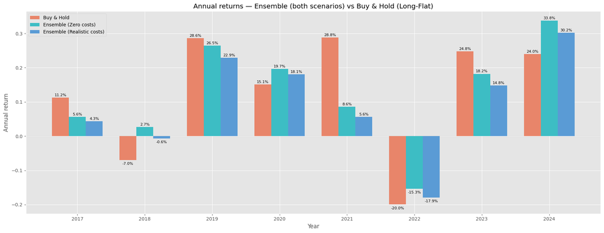

```python
# Yearly breakdown visualized
years     = sorted(yearly_df["year"].unique())
x         = np.arange(len(years))
width     = 0.25

bnh_vals  = yearly_df[yearly_df["strategy"] == "Buy & Hold"].set_index("year")["ann_return"]
zero_vals = yearly_df[yearly_df["strategy"] == "Ensemble (Zero costs)"].set_index("year")["ann_return"]
real_vals = yearly_df[yearly_df["strategy"] == "Ensemble (Realistic costs)"].set_index("year")["ann_return"]

with plt.style.context("ggplot"):
    fig, ax = plt.subplots(figsize=(18, 7))

    bars_bnh  = ax.bar(x - width, [bnh_vals[y]  for y in years], width, label="Buy & Hold",                 color="#E8856A")
    bars_zero = ax.bar(x,         [zero_vals[y] for y in years], width, label="Ensemble (Zero costs)",      color="#3DBDC4")
    bars_real = ax.bar(x + width, [real_vals[y] for y in years], width, label="Ensemble (Realistic costs)", color="#5A9BD5")

    for bars in [bars_bnh, bars_zero, bars_real]:
        for bar in bars:
            v = bar.get_height()
            ax.text(bar.get_x() + bar.get_width() / 2,
                    v + (0.002 if v >= 0 else -0.006),
                    f"{v:.1%}", ha="center", va="bottom" if v >= 0 else "top",
                    fontsize=8, color="#000000")

    ax.set_xticks(x)
    ax.set_xticklabels(years)
    ax.axhline(0, color="black", linewidth=0.8, zorder=0)
    ax.set_title("Annual returns — Ensemble (both scenarios) vs Buy & Hold (Long-Flat)")
    ax.set_ylabel("Annual return")
    ax.set_xlabel("Year")
    ax.legend()
    plt.tight_layout()
    plt.show()
```

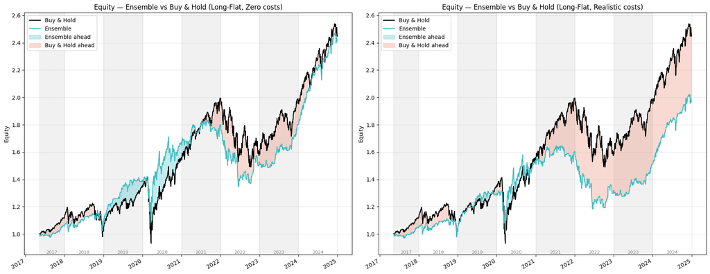

```python
# Ensemble vs Benchmark comparison
fig, axes = plt.subplots(1, 2, figsize=(18, 7))

for ax, scenario_name in zip(axes, ["Zero costs", "Realistic costs"]):
    ens_eq = results[scenario_name]["equity_lf"]["Ensemble"]
    bnh_eq = bnh_equity_global

    bnh_eq.plot(ax=ax, color="black",   linewidth=1.5, label="Buy & Hold", zorder=3)
    ens_eq.plot(ax=ax, color="#3DBDC4", linewidth=1.5, label="Ensemble",   zorder=3)

    years = sorted(ens_eq.index.year.unique())
    for i, year in enumerate(years):
        mask = ens_eq.index.year == year
        x0, x1 = ens_eq.index[mask][0], ens_eq.index[mask][-1]
        if i % 2 == 0:
            ax.axvspan(x0, x1, color="lightgrey", alpha=0.3, zorder=0)

    ax.fill_between(ens_eq.index, ens_eq, bnh_eq,
                    where=ens_eq >= bnh_eq, interpolate=True,
                    color="#3DBDC4", alpha=0.3, label="Ensemble ahead")
    ax.fill_between(ens_eq.index, ens_eq, bnh_eq,
                    where=ens_eq <  bnh_eq, interpolate=True,
                    color="#E8856A", alpha=0.3, label="Buy & Hold ahead")

    ymin = ax.get_ylim()[0]
    for year in years:
        mask = ens_eq.index.year == year
        x0, x1 = ens_eq.index[mask][0], ens_eq.index[mask][-1]
        ax.text(x0 + (x1 - x0) / 2, ymin, str(year),
                ha="center", va="bottom", fontsize=8, color="grey")

    ax.set_title(f"Equity — Ensemble vs Buy & Hold (Long-Flat, {scenario_name})")
    ax.set_ylabel("Equity")
    ax.set_xlabel("")
    ax.legend()
    ax.grid(alpha=0.3)

plt.tight_layout()
plt.show()
```

## Summary

### Zero transaction costs

- The long-flat Ensemble returns 12.22% annualised, nearly matching buy-and-hold (12.44%), with a better Sharpe ratio (0.68 vs 0.58) and lower max drawdown (−26.5% vs −34.1%).
- Best individual model: XGB-252 (long-flat) — Sharpe 0.67, annualised return 11.73%.
- Long-short strategies underperform long-flat across all models.

### Realistic transaction costs

- Costs significantly erode performance.
- The long-flat Ensemble drops to 9.27% annualised (Sharpe: 0.50).
- All models fall below the buy-and-hold benchmark.
- Long-short strategies are unsustainable — each reversal doubles the cost. The Ensemble reaches only 4.75% annualised.

### Best performer: Ensemble (long-flat)

- **Zero costs:** 12.22% annualised, Sharpe 0.68 — 0.22 pp below buy-and-hold in return, but better risk-adjusted performance and lower max drawdown (−26.5% vs −34.1%).
- **Realistic costs:** 9.27% annualised, Sharpe 0.50 — no longer beats buy-and-hold in return or on a risk-adjusted basis, though max drawdown remains lower (−28.2% vs −34.1%).